# Final project 220

Thy Bui

2024-04-22

# Introduction

In this report, we will investigate the number of people who have marked certain product as favorite based on ratings, reviews, price, the number of its variations and other charateristics (new, online, out of stock, sephora exlusive)

**Why does it matter?**

Researching and analysing the loved product help producers have an insight to consumer behavior and market trend. Therefore, they can build effective makerting campaigns and make more product development that brings more profit.

## Variables explanation

loves_count: The number of people who have marked this product as a favorite

rating: The average rating of the product based on user reviews

reviews: The number of user reviews for the product

size: The size of the product, which may be in oz, ml, g, packs, or other units depending on the product type

price_usd: The price of the product in US dollars

limited_edition: Indicates whether the product is a limited edition or not (1-true, 0-false)

new: Indicates whether the product is new or not (1-true, 0-false)

online_only: Indicates whether the product is only sold online or not (1-true, 0-false)

out_of_stock: Indicates whether the product is currently out of stock or not (1 if true, 0 if false)

sephora_exclusive: Indicates whether the product is exclusive to Sephora or not (1 if true, 0 if false)

child_count: The number of variations of the product available

```r
summary(product)
```

```
##   loves_count          rating         reviews          price_usd
##  Min.   :      0   Min.   :1.000   Min.   :    1.0   Min.   :   3.00
##  1st Qu.:   3758   1st Qu.:3.982   1st Qu.:   26.0   1st Qu.:  25.00
##  Median :   9880   Median :4.289   Median :  122.0   Median :  35.00
##  Mean   :  29180   Mean   :4.195   Mean   :  448.5   Mean   :  51.66
##  3rd Qu.:  26841   3rd Qu.:4.531   3rd Qu.:  418.0   3rd Qu.:  58.00
##  Max.   :1401068   Max.   :5.000   Max.   :21281.0   Max.   :1900.00
##                    NA's   :278     NA's   :278
##  limited_edition        new          online_only      out_of_stock
##  Min.   :0.00000   Min.   :0.0000   Min.   :0.0000   Min.   :0.0000
##  1st Qu.:0.00000   1st Qu.:0.0000   1st Qu.:0.0000   1st Qu.:0.0000
##  Median :0.00000   Median :0.0000   Median :0.0000   Median :0.0000
##  Mean   :0.07028   Mean   :0.0717   Mean   :0.2191   Mean   :0.0737
##  3rd Qu.:0.00000   3rd Qu.:0.0000   3rd Qu.:0.0000   3rd Qu.:0.0000
##  Max.   :1.00000   Max.   :1.0000   Max.   :1.0000   Max.   :1.0000
##
##  sephora_exclusive  child_count
##  Min.   :0.0000    Min.   :  0.000
##  1st Qu.:0.0000    1st Qu.:  0.000
##  Median :0.0000    Median :  0.000
##  Mean   :0.2794    Mean   :  1.632
##  3rd Qu.:1.0000    3rd Qu.:  1.000
##  Max.   :1.0000    Max.   :105.000
##
```

```r
str(product)
```

```
## 'data.frame':    8494 obs. of  10 variables:
##  $ loves_count      : int  6320 3827 3253 3018 2691 2448 1619 1542 1542 1377 ...
##  $ rating           : num  3.64 4.15 4.25 4.48 3.23 ...
##  $ reviews          : int  11 13 16 21 13 21 13 8 7 8 ...
##  $ price_usd        : num  35 195 195 195 195 30 30 195 195 30 ...
##  $ limited_edition  : int  0 0 0 0 0 0 0 0 0 0 ...
##  $ new              : int  0 0 0 0 0 0 0 0 0 0 ...
##  $ online_only      : int  1 1 1 1 1 1 1 1 1 1 ...
##  $ out_of_stock     : int  0 0 0 0 0 0 0 0 0 0 ...
##  $ sephora_exclusive: int  0 0 0 0 0 0 0 0 0 0 ...
##  $ child_count      : int  0 2 2 2 2 0 0 2 2 0 ...
```

We will do the NA omit as getting rid of these NA does not affect our dataset because the number of NA is small compared to the total observations we got.

Moreover, limited edition, new, online_only, out_of_stock, and sephora_exclusive are Bernoulli variables as they just have 1 and 0 values.

```r
product <- na.omit(product)
```

## Splitting data

```r
N <- seq(8216)
S <- sample(N,8216/2)
product_train <- product[S,]
product_test <- product[-S , ]
write.csv(product_test, "product_test.csv")
write.csv(product_train, "product_train.csv")
```

# Model testing

## Checking variables

First, we will do the histogram to check whether we should log the variable or not.

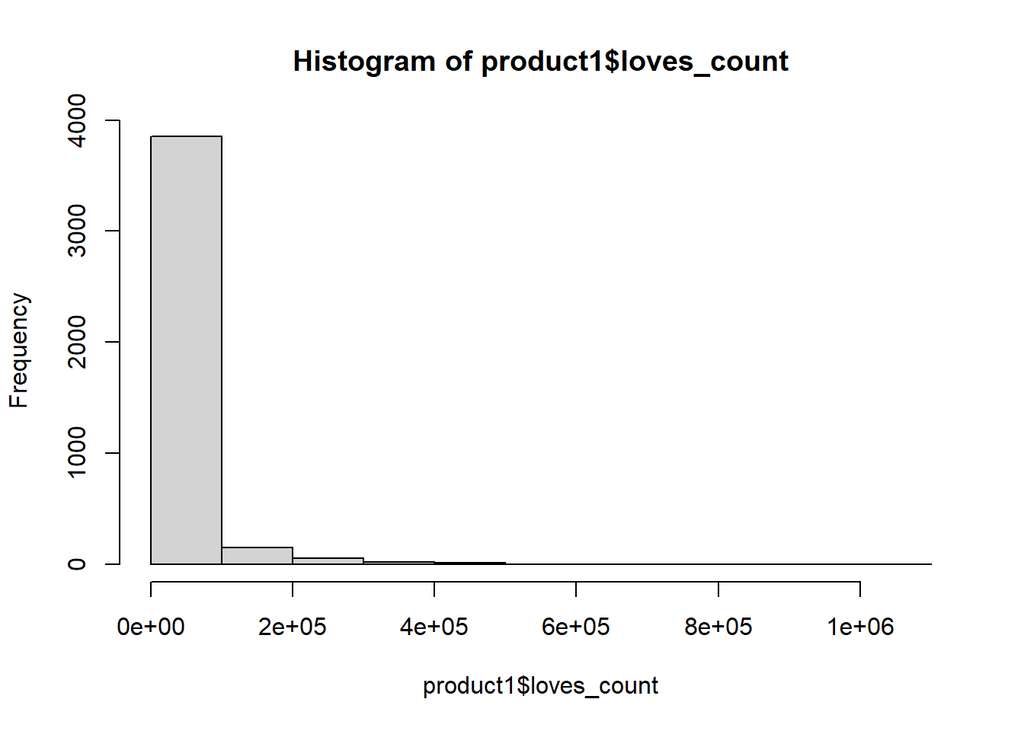

```r
product1 <- product_train
hist(product1$loves_count)
```

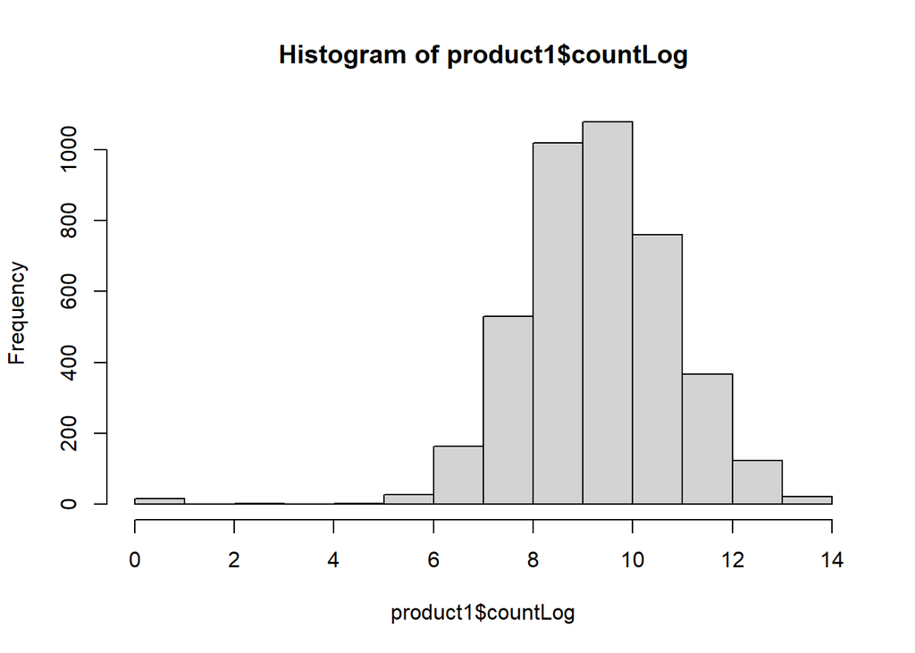

```r
product1 <- product1 %>%
  mutate(countLog = log(loves_count+1))
hist(product1$countLog)
```

The first model has a long tail and is skewed to the right so we consider logging these variables. After logging this variable, the histogram is normally distributed so we can conclude that logging this variable will significant improve our prediction.

Then, we will do the histogram for all the x variables to see whether we should log it or square it.

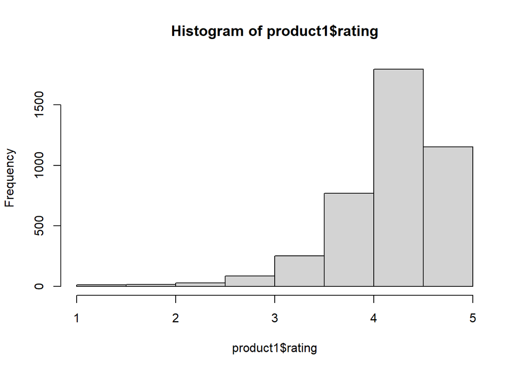

```r
hist(product1$rating)
```

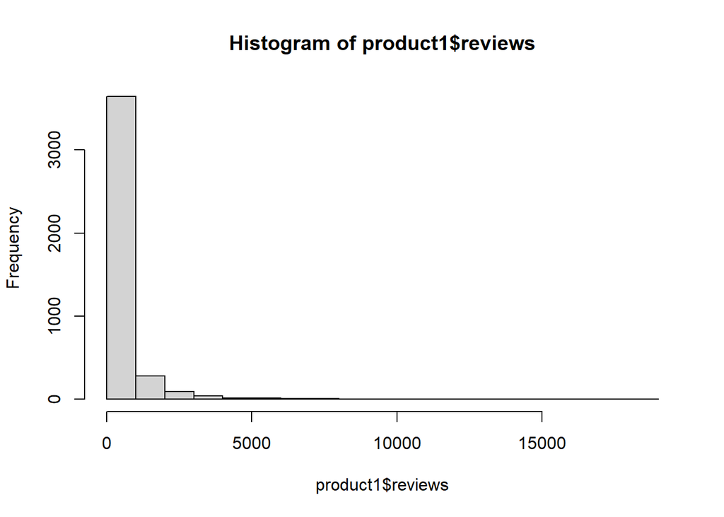

```r
hist(product1$reviews)
```

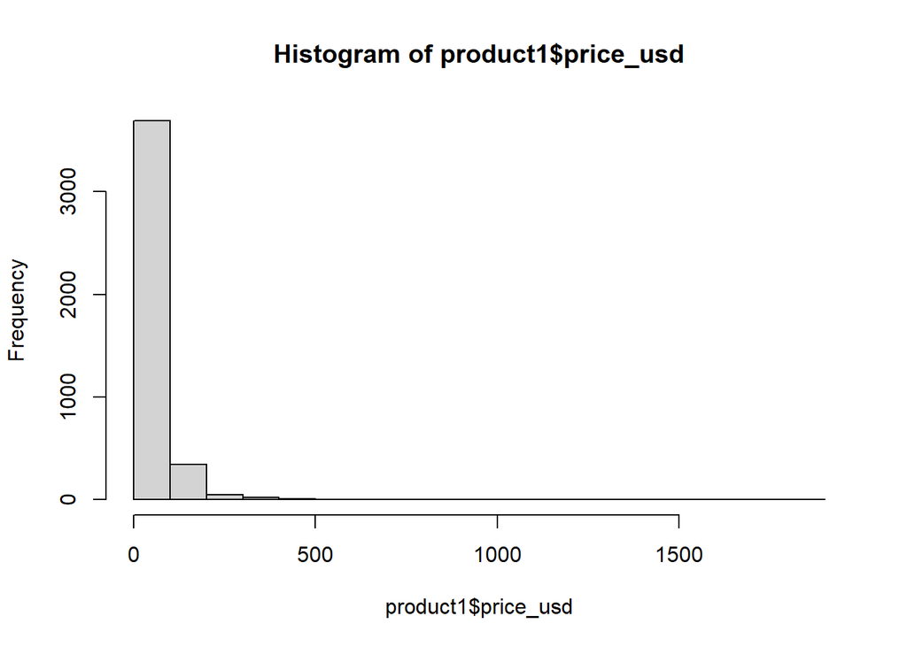

```r
hist(product1$price_usd)
```

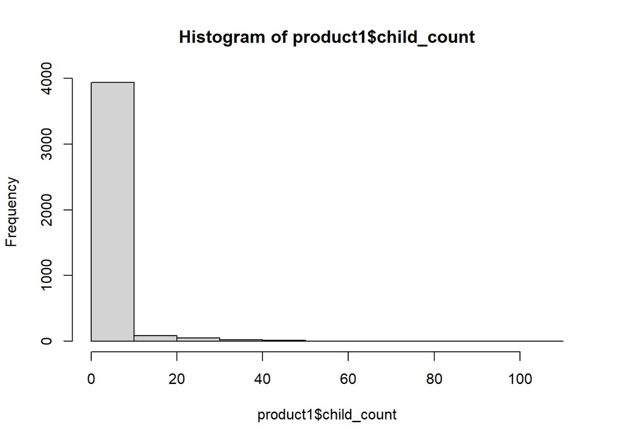

```r
hist(product1$child_count)
```

It turns out that the histogram for the reviews, price_usd, and child_count are skewed to the right and have a long tail so we consider logging these variables.

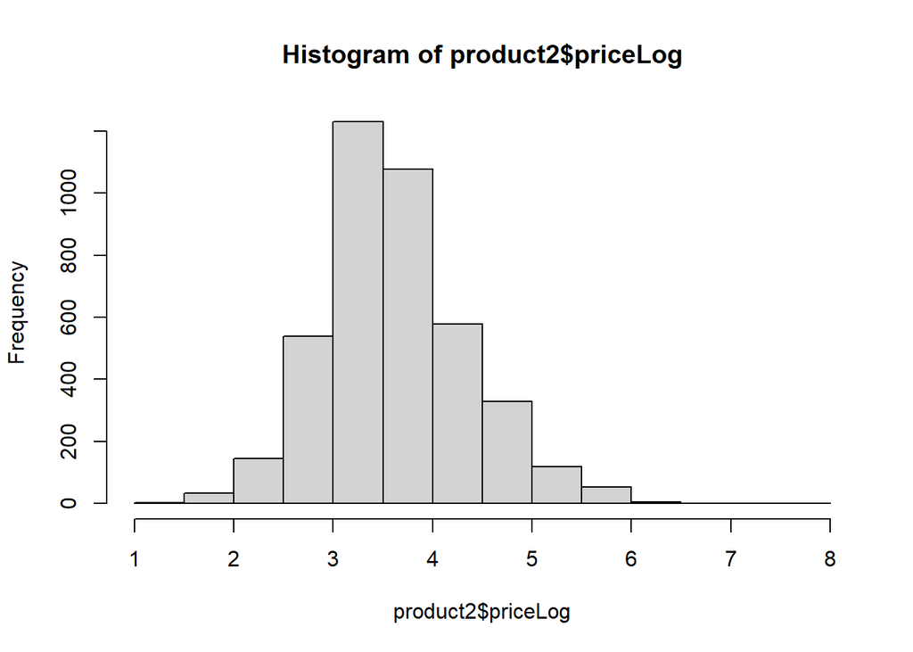

```r
product2 <- product1 %>%
  mutate(priceLog = log(price_usd)) %>%
  mutate(reviewsLog = log(reviews))%>%
  mutate(childLog = log(child_count+1))
hist(product2$priceLog)
```